# Linear Regression Project (Sri)

by Srinidhi (Sri) Manikantan

### 1) Loading and Viewing the Dataset

We will start off with loading the dataset that was provided to us. We will be using the head() function to briefly look through the dataset and get a sensing of what we are dealing with. head() will show the first few rows of the dataset

```r
df_reg <- read.csv("flightDelay2.csv", stringsAsFactors=TRUE)

head(df_reg)
```

```
##   YEAR MONTH DAY_OF_MONTH DEP_TIME DEP_DELAY TAXI_OUT WHEELS_OFF WHEELS_ON
## 1 2016    12            1     1646         1       20       1706      1822
## 2 2016    12            2     1640        -5       13       1653      1803
## 3 2016    12            4     1650         5       29       1719      1833
## 4 2016    12            5     1641        -4       36       1717      1831
## 5 2016    12            6     1646         1       15       1701      1813
## 6 2016    12            7     1642        -3       11       1653      1801
##   TAXI_IN ARR_TIME ARR_DELAY CANCELLED DIVERTED ACTUAL_ELAPSED_TIME DISTANCE
## 1       4     1826         4         0        0                 100      550
## 2       3     1806       -16         0        0                  86      550
## 3      12     1845        23         0        0                 115      550
## 4       8     1839        17         0        0                 118      550
## 5       4     1817        -5         0        0                  91      550
## 6       6     1807       -15         0        0                  85      550
##   CARRIER_DELAY WEATHER_DELAY NAS_DELAY SECURITY_DELAY LATE_AIRCRAFT_DELAY  X
## 1             0             0         0              0                   0 NA
## 2             0             0         0              0                   0 NA
## 3             0             0        18              0                   5 NA
## 4             0             0        17              0                   0 NA
## 5             0             0         0              0                   0 NA
## 6             0             0         0              0                   0 NA
```

### 2) Basic information about the dataset

First, we will start off by finding the number of rows and columns of our dataset. From the output below, we can see that there are **34314 rows and 21 columns.**

```r
dim(df_reg)
```

```
## [1] 34314    21
```

```r
str(df_reg)
```

```
## 'data.frame':    34314 obs. of  21 variables:
##  $ YEAR               : int  2016 2016 2016 2016 2016 2016 2016 2016 2016 2016 ...
##  $ MONTH              : int  12 12 12 12 12 12 12 12 12 12 ...
##  $ DAY_OF_MONTH       : int  1 2 4 5 6 7 8 9 11 12 ...
##  $ DEP_TIME           : int  1646 1640 1650 1641 1646 1642 1649 1636 1732 1640 ...
##  $ DEP_DELAY          : int  1 -5 5 -4 1 -3 4 -9 47 -5 ...
##  $ TAXI_OUT           : int  20 13 29 36 15 11 11 17 14 8 ...
##  $ WHEELS_OFF         : int  1706 1653 1719 1717 1701 1653 1700 1653 1746 1648 ...
##  $ WHEELS_ON          : int  1822 1803 1833 1831 1813 1801 1811 1809 1906 1800 ...
##  $ TAXI_IN            : int  4 3 12 8 4 6 4 3 3 3 ...
##  $ ARR_TIME           : int  1826 1806 1845 1839 1817 1807 1815 1812 1909 1803 ...
##  $ ARR_DELAY          : int  4 -16 23 17 -5 -15 -7 -10 47 -19 ...
##  $ CANCELLED          : int  0 0 0 0 0 0 0 0 0 0 ...
##  $ DIVERTED           : int  0 0 0 0 0 0 0 0 0 0 ...
##  $ ACTUAL_ELAPSED_TIME: int  100 86 115 118 91 85 86 96 97 83 ...
##  $ DISTANCE           : int  550 550 550 550 550 550 550 550 550 550 ...
##  $ CARRIER_DELAY      : int  0 0 0 0 0 0 0 0 0 0 ...
##  $ WEATHER_DELAY      : int  0 0 0 0 0 0 0 0 0 0 ...
##  $ NAS_DELAY          : int  0 0 18 17 0 0 0 0 0 0 ...
##  $ SECURITY_DELAY     : int  0 0 0 0 0 0 0 0 0 0 ...
##  $ LATE_AIRCRAFT_DELAY: int  0 0 5 0 0 0 0 0 47 0 ...
##  $ X                  : logi  NA NA NA NA NA NA ...
```

```r
summary(df_reg)
```

```
##       YEAR          MONTH     DAY_OF_MONTH      DEP_TIME      DEP_DELAY
##  Min.   :2016   Min.   :12   Min.   : 1.00   Min.   :   1   Min.   : -23.00
##  1st Qu.:2016   1st Qu.:12   1st Qu.: 8.00   1st Qu.: 958   1st Qu.:  -4.00
##  Median :2016   Median :12   Median :16.00   Median :1356   Median :  -1.00
##  Mean   :2016   Mean   :12   Mean   :15.88   Mean   :1387   Mean   :  15.57
##  3rd Qu.:2016   3rd Qu.:12   3rd Qu.:23.00   3rd Qu.:1822   3rd Qu.:  13.00
##  Max.   :2016   Max.   :12   Max.   :31.00   Max.   :2400   Max.   :1167.00
##                                              NA's   :881    NA's   :881
##     TAXI_OUT       WHEELS_OFF     WHEELS_ON       TAXI_IN           ARR_TIME
##  Min.   :  2.0   Min.   :   1   Min.   :   1   Min.   :  1.000   Min.   :   1
##  1st Qu.: 13.0   1st Qu.:1013   1st Qu.:1149   1st Qu.:  4.000   1st Qu.:1152
##  Median : 17.0   Median :1418   Median :1556   Median :  6.000   Median :1559
##  Mean   : 18.6   Mean   :1416   Mean   :1545   Mean   :  7.334   Mean   :1547
##  3rd Qu.: 21.0   3rd Qu.:1837   3rd Qu.:2004   3rd Qu.:  8.000   3rd Qu.:2007
##  Max.   :139.0   Max.   :2400   Max.   :2400   Max.   :150.000   Max.   :2400
##  NA's   :900     NA's   :900    NA's   :935    NA's   :935       NA's   :935
##    ARR_DELAY         CANCELLED          DIVERTED        ACTUAL_ELAPSED_TIME
##  Min.   : -52.00   Min.   :0.00000   Min.   :0.000000   Min.   : 29.0
##  1st Qu.: -11.00   1st Qu.:0.00000   1st Qu.:0.000000   1st Qu.: 98.0
##  Median :  -2.00   Median :0.00000   Median :0.000000   Median :133.0
##  Mean   :  12.23   Mean   :0.02634   Mean   :0.003002   Mean   :146.4
##  3rd Qu.:  15.00   3rd Qu.:0.00000   3rd Qu.:0.000000   3rd Qu.:180.0
##  Max.   :1189.00   Max.   :1.00000   Max.   :1.000000   Max.   :615.0
##  NA's   :1007                                           NA's   :1007
##     DISTANCE      CARRIER_DELAY      WEATHER_DELAY       NAS_DELAY
##  Min.   :  67.0   Min.   :   0.000   Min.   :  0.000   Min.   :  0.00
##  1st Qu.: 501.0   1st Qu.:   0.000   1st Qu.:  0.000   1st Qu.:  0.00
##  Median : 802.0   Median :   0.000   Median :  0.000   Median :  0.00
##  Mean   : 865.6   Mean   :   5.717   Mean   :  1.489   Mean   :  3.31
##  3rd Qu.:1182.0   3rd Qu.:   0.000   3rd Qu.:  0.000   3rd Qu.:  0.00
##  Max.   :4243.0   Max.   :1162.000   Max.   :935.000   Max.   :755.00
##
##  SECURITY_DELAY      LATE_AIRCRAFT_DELAY    X
##  Min.   : 0.000000   Min.   :  0.00      Mode:logical
##  1st Qu.: 0.000000   1st Qu.:  0.00      NA's:34314
##  Median : 0.000000   Median :  0.00
##  Mean   : 0.004197   Mean   :  6.09
##  3rd Qu.: 0.000000   3rd Qu.:  0.00
##  Max.   :30.000000   Max.   :582.00
##
```

### 3) Cleaning/Processing the dataset

rom our summary above, we can also see that certain columns are not informative and will not be meaningful for analysis. Let’s analyze further and determine if these columns should be removed

```r
length(unique(df_reg$YEAR))
```

```
## [1] 1
```

```r
length(unique(df_reg$MONTH))
```

```
## [1] 1
```

```r
length(unique(df_reg$X))
```

```
## [1] 1
```

Some variables like “YEAR”, “MONTH” and “X” have no unique values, while variables like “DAY OF MONTH” is too granular to produce any meaningful insights. **Hence, we will be dropping these uninformative columns from our dataset.**

**The columns dropped are: “YEAR”, “MONTH”, “DAY_OF_MONTH” and “X”**

```r
df = df_reg %>%
  select(-YEAR, -MONTH, -DAY_OF_MONTH, -X)
```

First, we will be checking to see if our dataset has any missing data and remove any rows that have any.

```r
w <- complete.cases(df)
df <- df[w,]

dim(df)
```

```
## [1] 33307    17
```

```r
dim(df_reg) - dim(df)
```

```
## [1] 1007    4
```

**This shows that 1007 rows and 4 columns have been removed from our data frame.**

```r
sapply(df, function(x) sum(is.na(x)))
```

```
##            DEP_TIME           DEP_DELAY            TAXI_OUT          WHEELS_OFF
##                   0                   0                   0                   0
##           WHEELS_ON             TAXI_IN            ARR_TIME           ARR_DELAY
##                   0                   0                   0                   0
##           CANCELLED            DIVERTED ACTUAL_ELAPSED_TIME            DISTANCE
##                   0                   0                   0                   0
##       CARRIER_DELAY       WEATHER_DELAY           NAS_DELAY      SECURITY_DELAY
##                   0                   0                   0                   0
## LATE_AIRCRAFT_DELAY
##                   0
```

This confirms that all our missing values have been removed successfully.

```r
str(df)
```

```
## 'data.frame':    33307 obs. of  17 variables:
##  $ DEP_TIME           : int  1646 1640 1650 1641 1646 1642 1649 1636 1732 1640 ...
##  $ DEP_DELAY          : int  1 -5 5 -4 1 -3 4 -9 47 -5 ...
##  $ TAXI_OUT           : int  20 13 29 36 15 11 11 17 14 8 ...
##  $ WHEELS_OFF         : int  1706 1653 1719 1717 1701 1653 1700 1653 1746 1648 ...
##  $ WHEELS_ON          : int  1822 1803 1833 1831 1813 1801 1811 1809 1906 1800 ...
##  $ TAXI_IN            : int  4 3 12 8 4 6 4 3 3 3 ...
##  $ ARR_TIME           : int  1826 1806 1845 1839 1817 1807 1815 1812 1909 1803 ...
##  $ ARR_DELAY          : int  4 -16 23 17 -5 -15 -7 -10 47 -19 ...
##  $ CANCELLED          : int  0 0 0 0 0 0 0 0 0 0 ...
##  $ DIVERTED           : int  0 0 0 0 0 0 0 0 0 0 ...
##  $ ACTUAL_ELAPSED_TIME: int  100 86 115 118 91 85 86 96 97 83 ...
##  $ DISTANCE           : int  550 550 550 550 550 550 550 550 550 550 ...
##  $ CARRIER_DELAY      : int  0 0 0 0 0 0 0 0 0 0 ...
##  $ WEATHER_DELAY      : int  0 0 0 0 0 0 0 0 0 0 ...
##  $ NAS_DELAY          : int  0 0 18 17 0 0 0 0 0 0 ...
##  $ SECURITY_DELAY     : int  0 0 0 0 0 0 0 0 0 0 ...
##  $ LATE_AIRCRAFT_DELAY: int  0 0 5 0 0 0 0 0 47 0 ...
```

We also see that some variables like “CANCELLED”, “DIVERTED”, “CARRIER_DELAY”, “WEATHER_DELAY” and “SECURITY_DELAY” have a lot of zeros in their columns. Let’s analyze these variables.

```r
low_variance_cols <- names(df)[apply(df, 2, var) == 0]
low_variance_cols
```

```
## [1] "CANCELLED" "DIVERTED"
```

```r
df <- df %>%
  select(-CANCELLED, -DIVERTED)
```

**We have also dropped two low variance columns that will not be meaningful for our analysis: “CANCELLED” and “DIVERTED”.**

```r
summary(df)
```

```
##     DEP_TIME      DEP_DELAY          TAXI_OUT        WHEELS_OFF
##  Min.   :   1   Min.   : -23.00   Min.   :  2.00   Min.   :   1
##  1st Qu.: 958   1st Qu.:  -4.00   1st Qu.: 13.00   1st Qu.:1013
##  Median :1357   Median :  -1.00   Median : 17.00   Median :1418
##  Mean   :1387   Mean   :  15.48   Mean   : 18.59   Mean   :1416
##  3rd Qu.:1822   3rd Qu.:  13.00   3rd Qu.: 21.00   3rd Qu.:1837
##  Max.   :2400   Max.   :1167.00   Max.   :139.00   Max.   :2400
##    WHEELS_ON       TAXI_IN           ARR_TIME      ARR_DELAY
##  Min.   :   1   Min.   :  1.000   Min.   :   1   Min.   : -52.00
##  1st Qu.:1149   1st Qu.:  4.000   1st Qu.:1152   1st Qu.: -11.00
##  Median :1556   Median :  6.000   Median :1559   Median :  -2.00
##  Mean   :1545   Mean   :  7.332   Mean   :1547   Mean   :  12.23
##  3rd Qu.:2004   3rd Qu.:  8.000   3rd Qu.:2008   3rd Qu.:  15.00
##  Max.   :2400   Max.   :150.000   Max.   :2400   Max.   :1189.00
##  ACTUAL_ELAPSED_TIME    DISTANCE      CARRIER_DELAY     WEATHER_DELAY
##  Min.   : 29.0       Min.   :  67.0   Min.   :   0.00   Min.   :  0.000
##  1st Qu.: 98.0       1st Qu.: 528.0   1st Qu.:   0.00   1st Qu.:  0.000
##  Median :133.0       Median : 802.0   Median :   0.00   Median :  0.000
##  Mean   :146.4       Mean   : 870.7   Mean   :   5.89   Mean   :  1.534
##  3rd Qu.:180.0       3rd Qu.:1182.0   3rd Qu.:   0.00   3rd Qu.:  0.000
##  Max.   :615.0       Max.   :4243.0   Max.   :1162.00   Max.   :935.000
##    NAS_DELAY      SECURITY_DELAY      LATE_AIRCRAFT_DELAY
##  Min.   :  0.00   Min.   : 0.000000   Min.   :  0.000
##  1st Qu.:  0.00   1st Qu.: 0.000000   1st Qu.:  0.000
##  Median :  0.00   Median : 0.000000   Median :  0.000
##  Mean   :  3.41   Mean   : 0.004323   Mean   :  6.274
##  3rd Qu.:  0.00   3rd Qu.: 0.000000   3rd Qu.:  0.000
##  Max.   :755.00   Max.   :30.000000   Max.   :582.000
```

### 4) Understanding the correlations of our predictor and response variables

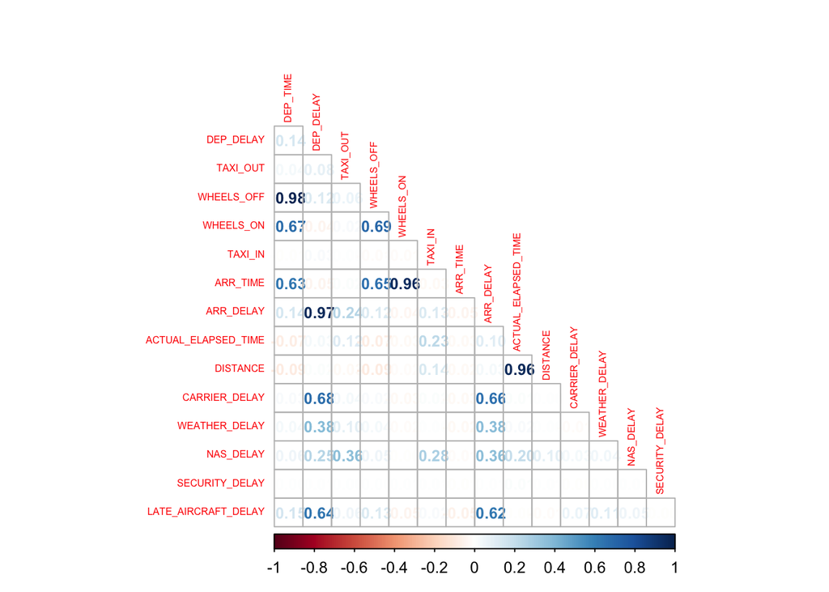

```r
correlation_matrix = cor(df)
corrplot(correlation_matrix, diag = FALSE, method="number", type = 'lower', addCoef.col = 1,number.cex = 0.8, tl.cex = 0.5)
```

From the above correlation plot, you can see that there are 4 highly correlated variables with correlation around 0.96-0.98. I have summarized the 4 correlation pairs and a possible explanation below:

[output not shown]

There are also 8 other pair of variables that are moderately correlated with correlation around 0.62 - 0.69.

### 5) Identifying and removing outliers (if any)

First, we will look at the distribution of our variables - which is an important key step before determining if values are outliers and hence have to be removed.

```r
df_numeric <- df %>%
  select_if(is.numeric)
```

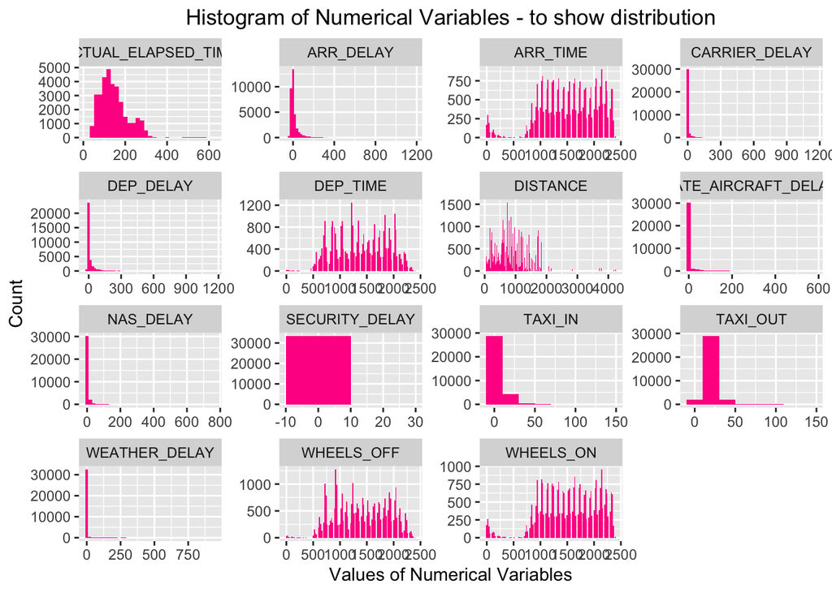

```r
#understanding the distribution of our numeric variables
df_numeric %>%
  gather(key="Variables", value = "Value") %>%
  ggplot(., aes(x=Value)) +
  facet_wrap(~ Variables , ncol = 4, scales= "free") +
  geom_histogram(fill="deeppink", binwidth = 20) +
  ggtitle("Histogram of Numerical Variables - to show distribution") +
  theme(plot.title = element_text(hjust = 0.5)) +
  labs(x = "Values of Numerical Variables", y="Count")
```

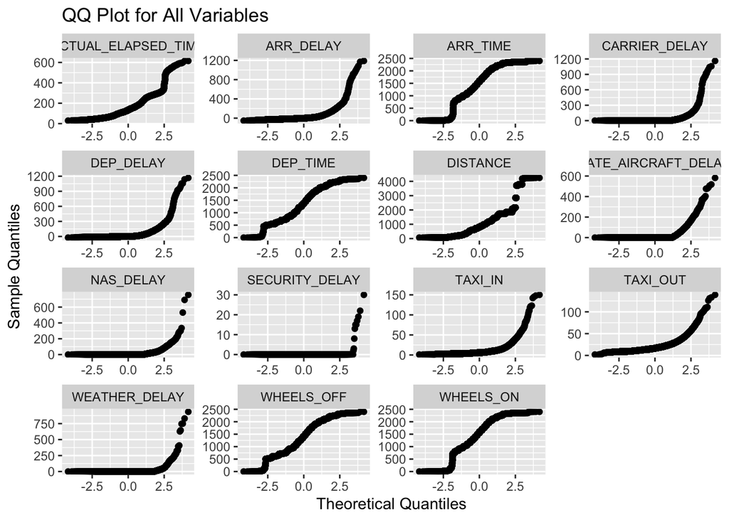

```r
df_numeric %>%
  gather(key="Variables", value = "Value") %>%
  ggplot(., aes(sample=Value)) +
  facet_wrap(~ Variables, scales= "free") +
  stat_qq() +
  labs(title = "QQ Plot for All Variables",
       x = "Theoretical Quantiles",
       y = "Sample Quantiles")
```

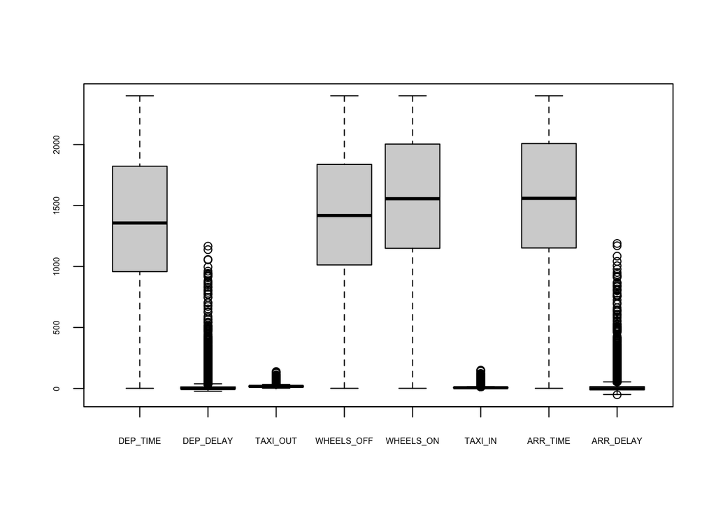

```r
df_numeric %>%
  select("DEP_TIME", "DEP_DELAY", "TAXI_OUT", "WHEELS_OFF", "WHEELS_ON", "TAXI_IN", "ARR_TIME", "ARR_DELAY") %>%
  boxplot(., outline = TRUE, cex.axis = 0.5)
```

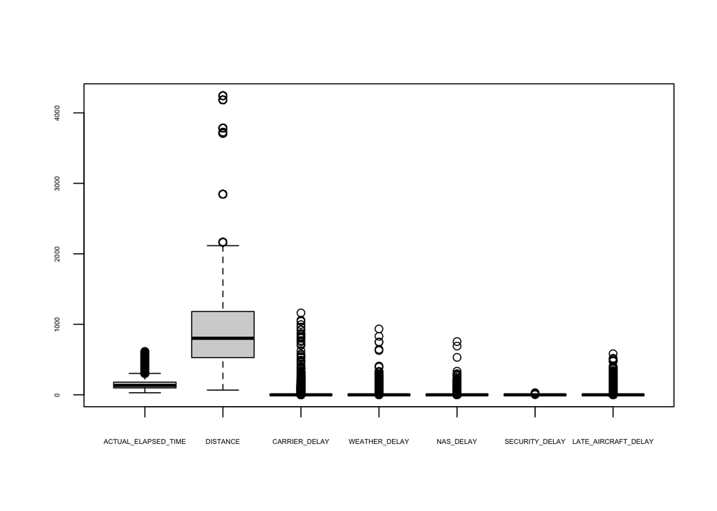

```r
df %>%
  select(-c("DEP_TIME", "DEP_DELAY", "TAXI_OUT", "WHEELS_OFF", "WHEELS_ON", "TAXI_IN", "ARR_TIME", "ARR_DELAY")) %>%
  boxplot(., outline = TRUE, cex.axis = 0.4)
```

From the outliers, we can see that we do have a significant proportion of data that are identified as outliers for each variable. Let’s use the box-plot method to actually count the number of outliers.

```r
outliers <- boxplot(df_numeric, plot = FALSE)$out
num_outliers <- length(outliers)

num_outliers
```

```
## [1] 26690
```

The boxplot method have identified 26690 outliers in our dataset. We will be cross checking this with another outlier identification method (i.e. using IQR) to check how many outliers there will be.

```r
df_numeric1 <- df_numeric  # Create a new dataframe as a copy of df_numeric

for (col in names(df_numeric1)) {
  if (sum(!is.na(df_numeric1[[col]])) > 0) {  # Check if there are non-NA values
    Q1 <- quantile(df_numeric1[[col]], probs = 0.25, na.rm = TRUE)
    Q3 <- quantile(df_numeric1[[col]], probs = 0.75, na.rm = TRUE)
    IQR_value <- Q3 - Q1
    lower_bound <- Q1 - 1.5 * IQR_value
    upper_bound <- Q3 + 1.5 * IQR_value

    # Identify outliers and replace them with NA for the specific column in df_numeric1
    df_numeric1[[col]][df_numeric1[[col]] < lower_bound | df_numeric1[[col]] > upper_bound] <- NA
  }
}

# Print the cleaned data in df_numeric1
head(df_numeric1)
```

```
##   DEP_TIME DEP_DELAY TAXI_OUT WHEELS_OFF WHEELS_ON TAXI_IN ARR_TIME ARR_DELAY
## 1     1646         1       20       1706      1822       4     1826         4
## 2     1640        -5       13       1653      1803       3     1806       -16
## 3     1650         5       29       1719      1833      12     1845        23
## 4     1641        -4       NA       1717      1831       8     1839        17
## 5     1646         1       15       1701      1813       4     1817        -5
## 6     1642        -3       11       1653      1801       6     1807       -15
##   ACTUAL_ELAPSED_TIME DISTANCE CARRIER_DELAY WEATHER_DELAY NAS_DELAY
## 1                 100      550             0             0         0
## 2                  86      550             0             0         0
## 3                 115      550             0             0        NA
## 4                 118      550             0             0        NA
## 5                  91      550             0             0         0
## 6                  85      550             0             0         0
##   SECURITY_DELAY LATE_AIRCRAFT_DELAY
## 1              0                   0
## 2              0                   0
## 3              0                  NA
## 4              0                   0
## 5              0                   0
## 6              0                   0
```

```r
w <- complete.cases(df_numeric1)
df_numeric1 <- df_numeric1[w,]

dim(df_numeric1)
```

```
## [1] 23026    15
```

```r
dim(df_numeric) - dim(df_numeric1)
```

```
## [1] 10281     0
```

We tried two methods of identifying outliers - box-plot method and IQR method. Both approaches have identified a large proportion of dataset to be outliers (~26000 for box-plot and ~10000 for IQR method). There is a possibility that these values are NOT outliers. Given the unpredictability of airplane travel and timing, it is possible that the range of these values just tend to be high and varied, causing these values to be identified as outliers.

**As such, for the purpose of our analysis, we will not be removing any outliers from our dataset.**

### 6) Splitting data into training and test sets

```r
set.seed(404)
s <- sample(nrow(df),round(0.7*nrow(df)))

df.train <- df[s,]
df.test <- df[-s,]
```

### 7) Analysis with Linear Regression

```r
# Fit a linear regression model
lm.out <- lm(ARR_DELAY~., data = df.train)
arr.pred <- predict(lm.out,newdata=df.test)

# Summarize the model
summary(lm.out)
```

```
##
## Call:
## lm(formula = ARR_DELAY ~ ., data = df.train)
##
## Residuals:
##     Min      1Q  Median      3Q     Max
## -36.923  -3.842   0.408   4.259  74.037
##
## Coefficients:
##                       Estimate Std. Error  t value Pr(>|t|)
## (Intercept)         -2.350e+01  2.043e-01 -115.030  < 2e-16 ***
## DEP_TIME             1.124e-04  4.683e-04    0.240 0.810390
## DEP_DELAY            6.037e-01  4.777e-03  126.393  < 2e-16 ***
## TAXI_OUT             3.491e-01  6.369e-03   54.810  < 2e-16 ***
## WHEELS_OFF          -1.390e-04  4.728e-04   -0.294 0.768764
## WHEELS_ON            1.080e-03  2.871e-04    3.761 0.000169 ***
## TAXI_IN              2.350e-01  7.753e-03   30.307  < 2e-16 ***
## ARR_TIME            -5.444e-04  2.688e-04   -2.025 0.042892 *
## ACTUAL_ELAPSED_TIME  2.865e-01  2.956e-03   96.942  < 2e-16 ***
## DISTANCE            -3.630e-02  3.897e-04  -93.129  < 2e-16 ***
## CARRIER_DELAY        4.042e-01  5.045e-03   80.125  < 2e-16 ***
## WEATHER_DELAY        3.940e-01  5.461e-03   72.141  < 2e-16 ***
## NAS_DELAY            4.504e-01  5.022e-03   89.683  < 2e-16 ***
## SECURITY_DELAY       3.488e-01  1.722e-01    2.026 0.042769 *
## LATE_AIRCRAFT_DELAY  4.079e-01  5.214e-03   78.241  < 2e-16 ***
## ---
## Signif. codes:  0 '***' 0.001 '**' 0.01 '*' 0.05 '.' 0.1 ' ' 1
##
## Residual standard error: 6.391 on 23300 degrees of freedom
## Multiple R-squared:  0.9851, Adjusted R-squared:  0.9851
## F-statistic: 1.104e+05 on 14 and 23300 DF,  p-value: < 2.2e-16
```

```r
# Calculate residuals
residuals <- df.test$ARR_DELAY - arr.pred

# Calculate Mean Squared Error (MSE)
mse <- mean(residuals^2)

# Display the MSE
cat("Mean Squared Error (MSE):", mse, "\n")
```

```
## Mean Squared Error (MSE): 40.04337
```

MSE represents the average squared difference between the actual observed values and the values predicted by the linear model. A MSE of 40.04 suggests that, on average, your model’s predictions are off by the square root of 40.04, which is approximately 6.33. This means that the model’s predictions deviate from the true values by about 6.33 units on average.

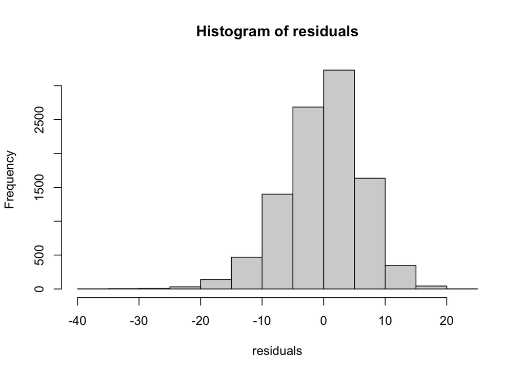

```r
hist(residuals)
```

From the output above, we can see that our residuals are normally distributed and roughly have a symmetric distribution (although slightly left skewed). This is a key assumption of linear regression, and our histogram plot proves that the assumption is met.

We can also see that the histogram is centered around zero, which shows that our linear model is generally well-fitted and our model is good at making unbiased predictions.

```r
summary(lm.out)$adj.r.squared
```

```
## [1] 0.9851387
```

The adjusted R-squared is 0.985, which is very close to 1. This means that a great proportion of the variance in our response variable can be explained by our predictor variables. Hence, we can conclude that the linear regression model is informative/useful and could be a good fit for our dataset.

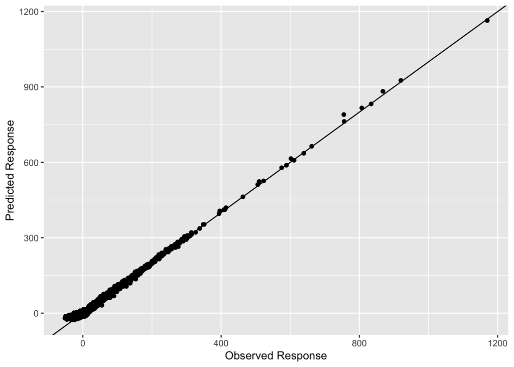

```r
df.plot <- data.frame("x"=df.test$ARR_DELAY,"y"=arr.pred)
ggplot(data = df.plot, aes(x = df.test$ARR_DELAY, y = arr.pred)) + geom_point() + geom_abline() +
  xlab("Observed Response") +
  ylab("Predicted Response")
```

The linear model does not tend to break at all, and it shows how all the points nicely fall on/near the diagonal line.

### 8) Computation of variance-inflation factors

```r
suppressMessages(library(car))
lm.out <- lm(ARR_DELAY~.,data=df.train)
vif_values <- vif(lm.out)
vif_values
```

```
##            DEP_TIME           DEP_DELAY            TAXI_OUT          WHEELS_OFF
##           28.735236           32.863373            1.645169           29.495626
##           WHEELS_ON             TAXI_IN            ARR_TIME ACTUAL_ELAPSED_TIME
##           12.653472            1.313574           11.411828           24.657178
##            DISTANCE       CARRIER_DELAY       WEATHER_DELAY           NAS_DELAY
##           23.414353           15.506796            4.606551            3.167215
##      SECURITY_DELAY LATE_AIRCRAFT_DELAY
##            1.001509           10.471484
```

VIF is a measure that helps to assess multicollinearity. This happens when two or more predictor variables in a regression model are highly correlated with each other. High VIF values indicate that a variable is highly collinear with other predictors, which can lead to unstable coefficient estimates.

A VIF of 1 indicates no multicollinearity, while a VIF greater than 1 suggests increasing levels of multicollinearity. Generally, a VIF value above 5 or 10 is often considered a sign of problematic multicollinearity.

From our output above, we can see that there is a sign of problematic multicollinearity where more than one predictor variables have high VIF coefficients. Hence, we can see that more than 1 predictor variable is correlated with other predictors in a way that makes it difficult to disentangle their individual effects.

We had previously identified some highly correlated variables in our correlation plot. We will remove one variable from each pair and run VIF again to see if the scores improve.

```r
df_new = df %>%
  select(-c(WHEELS_OFF, WHEELS_ON, DEP_DELAY, ACTUAL_ELAPSED_TIME))

df_new.train <- df_new[s,]
df_new.test <- df_new[-s,]
```

```r
lm.out <- lm(ARR_DELAY~.,data=df_new.train)
vif_values <- vif(lm.out)
vif_values
```

```
##            DEP_TIME            TAXI_OUT             TAXI_IN            ARR_TIME
##            1.813436            1.168104            1.107054            1.761200
##            DISTANCE       CARRIER_DELAY       WEATHER_DELAY           NAS_DELAY
##            1.039726            1.008527            1.021321            1.258260
##      SECURITY_DELAY LATE_AIRCRAFT_DELAY
##            1.000047            1.080331
```

From the above output, we can see that all of our variables have the expected of VIF values around 1, showing that there is no issue of multicollinearity.

### 9) Best-subset selection analysis of the dataset

```r
#removing the response variable from our dataset
df_new1.train <- df_new.train %>%
  select(-c("ARR_DELAY"))

df_new1.test <- df_new.test %>%
  select(-c("ARR_DELAY"))
```

```r
#reinserting the y-variable in the last column as as "y" as that is the format bestglm expects the response variable to be
y <- df_new.train$ARR_DELAY
y <- df_new1.train <- data.frame(df_new1.train,"y"=y)

y <- df_new.test$ARR_DELAY
df_new1.test <- data.frame(df_new1.test,"y"=y)
```

```r
suppressMessages(library(bestglm))
out.bg.bic <- bestglm(df_new1.train,family=gaussian,IC="BIC")
out.bg.bic$BestModel
```

```
##
## Call:
## lm(formula = y ~ ., data = data.frame(Xy[, c(bestset[-1], FALSE),
##     drop = FALSE], y = y))
##
## Coefficients:
##         (Intercept)             DEP_TIME             TAXI_OUT
##          -1.604e+01            1.475e-03            3.573e-01
##             TAXI_IN             DISTANCE        CARRIER_DELAY
##           2.181e-01            8.312e-04            1.022e+00
##       WEATHER_DELAY            NAS_DELAY       SECURITY_DELAY
##           1.005e+00            9.714e-01            1.252e+00
## LATE_AIRCRAFT_DELAY
##           1.030e+00
```

```r
out.bg.aic <- bestglm(df_new1.train,family=gaussian,IC="AIC")
out.bg.aic$BestModel
```

```
##
## Call:
## lm(formula = y ~ ., data = data.frame(Xy[, c(bestset[-1], FALSE),
##     drop = FALSE], y = y))
##
## Coefficients:
##         (Intercept)             DEP_TIME             TAXI_OUT
##          -1.591e+01            1.663e-03            3.577e-01
##             TAXI_IN             ARR_TIME             DISTANCE
##           2.180e-01           -2.587e-04            8.418e-04
##       CARRIER_DELAY        WEATHER_DELAY            NAS_DELAY
##           1.022e+00            1.005e+00            9.710e-01
##      SECURITY_DELAY  LATE_AIRCRAFT_DELAY
##           1.252e+00            1.030e+00
```

From the above output, we can see that BIC model retained 9 out of the 10 predictor variables, while AIC model retained all of the 10 predictor variables.

Moreover, if we compare the coefficients of the common predictor variables between AIC and BIC, we can see that they are almost the same/or very similar showing that the model’s performance, as indicated by both AIC and BIC, appears to be relatively consistent and stable with these predictors.

A model with similar predictors and coefficients based on both AIC and BIC is less likely to suffer from overfitting as it avoids unnecessary complexity. This gives us more confidence in our selected model.

```r
aic.pred <- predict(out.bg.aic$BestModel,newdata=df_new1.test)
mean((df_new1.test$y-aic.pred)^2)
```

```
## [1] 74.97857
```

```r
bic.pred <- predict(out.bg.bic$BestModel,newdata=df_new1.test)
mean((df_new1.test$y-bic.pred)^2)
```

```
## [1] 75.00188
```

```r
summary(out.bg.aic$BestModel)$adj.r.squared
```

```
## [1] 0.9725143
```

```r
summary(out.bg.bic$BestModel)$adj.r.squared
```

```
## [1] 0.9725117
```

As such, we may have to reconsider the dropped variables. We will try this again on the original df.train (i.e. without the dropping of correlated variables)

```r
df1.train <- df.train %>%
  select(-c("ARR_DELAY"))

df1.test <- df.test %>%
  select(-c("ARR_DELAY"))
```

```r
y <- df.train$ARR_DELAY
y <- df1.train <- data.frame(df1.train,"y"=y)

y <- df.test$ARR_DELAY
df1.test <- data.frame(df1.test,"y"=y)
```

```r
out.bg.bic <- bestglm(df1.train,family=gaussian,IC="BIC")
out.bg.bic$BestModel
```

```
##
## Call:
## lm(formula = y ~ ., data = data.frame(Xy[, c(bestset[-1], FALSE),
##     drop = FALSE], y = y))
##
## Coefficients:
##         (Intercept)            DEP_DELAY             TAXI_OUT
##          -2.354e+01            6.039e-01            3.491e-01
##           WHEELS_ON              TAXI_IN  ACTUAL_ELAPSED_TIME
##           5.343e-04            2.358e-01            2.865e-01
##            DISTANCE        CARRIER_DELAY        WEATHER_DELAY
##          -3.630e-02            4.041e-01            3.938e-01
##           NAS_DELAY  LATE_AIRCRAFT_DELAY
##           4.503e-01            4.078e-01
```

```r
out.bg.aic <- bestglm(df1.train,family=gaussian,IC="AIC")
out.bg.aic$BestModel
```

```
##
## Call:
## lm(formula = y ~ ., data = data.frame(Xy[, c(bestset[-1], FALSE),
##     drop = FALSE], y = y))
##
## Coefficients:
##         (Intercept)            DEP_DELAY             TAXI_OUT
##          -2.350e+01            6.036e-01            3.489e-01
##           WHEELS_ON              TAXI_IN             ARR_TIME
##           1.059e-03            2.350e-01           -5.424e-04
## ACTUAL_ELAPSED_TIME             DISTANCE        CARRIER_DELAY
##           2.865e-01           -3.629e-02            4.043e-01
##       WEATHER_DELAY            NAS_DELAY       SECURITY_DELAY
##           3.940e-01            4.504e-01            3.490e-01
## LATE_AIRCRAFT_DELAY
##           4.080e-01
```

```r
aic.pred <- predict(out.bg.aic$BestModel,newdata=df1.test)
mean((df1.test$y-aic.pred)^2)
```

```
## [1] 40.04303
```

```r
bic.pred <- predict(out.bg.bic$BestModel,newdata=df1.test)
mean((df1.test$y-bic.pred)^2)
```

```
## [1] 40.07045
```

```r
summary(out.bg.aic$BestModel)$adj.r.squared
```

```
## [1] 0.9851399
```

```r
summary(out.bg.bic$BestModel)$adj.r.squared
```

```
## [1] 0.9851359
```

### 10) Simple PCA Analysis on predictors

```r
df_noresp <- df %>%
  select(-c("ARR_DELAY"))
```

```r
pca.out <- prcomp(df_noresp,scale=TRUE)
v <- summary(pca.out)$sdev^2
cumulative_var = round(cumsum(v/sum(v)),3)
cumulative_var
```

```
##  [1] 0.238 0.399 0.543 0.635 0.709 0.781 0.850 0.912 0.953 0.993 0.996 0.998
## [13] 0.999 1.000
```

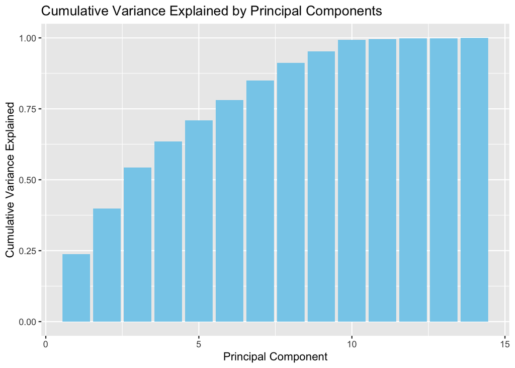

```r
cumulative_data <- data.frame(
  PC = 1:length(cumulative_var),  # Principal Component number
  Cumulative_Variance = cumulative_var  # Cumulative Variance Explained
)

ggplot(cumulative_data, aes(x = PC, y = Cumulative_Variance)) +
  geom_bar(stat = "identity", fill = "skyblue") +
  labs(title = "Cumulative Variance Explained by Principal Components",
       x = "Principal Component",
       y = "Cumulative Variance Explained")
```

From the output above, we can also see how 10 PE variables are able to explain almost 100% of the explained variance in the dataset (this is similar to what we observed for our best-subset selection analysis)

```r
round(pca.out$rotation[,1:9],3)
```

```
##                        PC1    PC2    PC3    PC4    PC5    PC6    PC7    PC8
## DEP_TIME            -0.502  0.045  0.010 -0.012  0.025 -0.010 -0.090 -0.098
## DEP_DELAY           -0.067  0.520  0.397 -0.156 -0.041 -0.003  0.020  0.042
## TAXI_OUT            -0.036  0.200 -0.009  0.600  0.143  0.059  0.471 -0.194
## WHEELS_OFF          -0.505  0.036 -0.002  0.003  0.026 -0.008 -0.067 -0.091
## WHEELS_ON           -0.491 -0.063 -0.142 -0.036 -0.037  0.001  0.072  0.112
## TAXI_IN              0.020  0.202 -0.187  0.248 -0.368 -0.078 -0.661  0.317
## ARR_TIME            -0.479 -0.073 -0.142 -0.043 -0.037  0.017  0.087  0.118
## ACTUAL_ELAPSED_TIME  0.071  0.385 -0.535 -0.172  0.080  0.021  0.092 -0.063
## DISTANCE             0.075  0.339 -0.530 -0.305  0.099  0.022  0.088 -0.066
## CARRIER_DELAY       -0.021  0.322  0.277 -0.247 -0.550 -0.022  0.390  0.247
## WEATHER_DELAY       -0.023  0.223  0.163  0.034  0.663  0.054 -0.047  0.648
## NAS_DELAY           -0.023  0.325 -0.083  0.590 -0.154 -0.008 -0.031 -0.025
## SECURITY_DELAY      -0.001  0.011 -0.009  0.008  0.090 -0.993  0.075 -0.007
## LATE_AIRCRAFT_DELAY -0.061  0.337  0.299 -0.131  0.220  0.002 -0.371 -0.571
##                        PC9
## DEP_TIME            -0.409
## DEP_DELAY            0.028
## TAXI_OUT             0.316
## WHEELS_OFF          -0.387
## WHEELS_ON            0.363
## TAXI_IN              0.250
## ARR_TIME             0.415
## ACTUAL_ELAPSED_TIME -0.019
## DISTANCE            -0.055
## CARRIER_DELAY       -0.007
## WEATHER_DELAY       -0.032
## NAS_DELAY           -0.342
## SECURITY_DELAY       0.014
## LATE_AIRCRAFT_DELAY  0.306
```

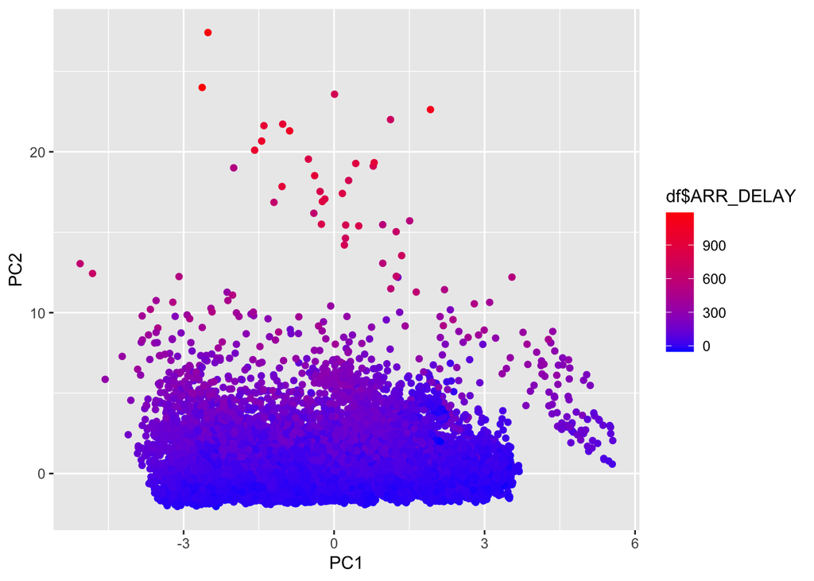

```r
data <- data.frame(
  PC1 = pca.out$x[,1],
  PC2 = pca.out$x[,2])

ggplot(data, aes(x=PC1, y=PC2, color=df$ARR_DELAY)) +
  geom_point() +
  scale_color_gradient(low = "blue", high = "red")
```

```r
df_pca = data.frame(pca.out$x[, 1:10])
pc.train <- df_pca[s, ]
pc.test <- df_pca[-s, ]
```

```r
lm.out <- lm(ARR_DELAY ~., data = cbind(pc.train, ARR_DELAY = df$ARR_DELAY[s]))
arr.pred <- predict(lm.out,newdata = cbind(pc.test, ARR_DELAY = df$ARR_DELAY[-s]))
```

```r
residuals <- df$ARR_DELAY[-s] - arr.pred

# Calculate Mean Squared Error (MSE)
mse <- mean(residuals^2)

# Display the MSE
cat("Mean Squared Error (MSE):", mse, "\n")
```

```
## Mean Squared Error (MSE): 54.79856
```

```r
summary(lm.out)$adj.r.squared
```

```
## [1] 0.9796353
```

The MSE is higher than what we had observed for our latest best-subset model analysis, and the adjusted R-squared value dropped slightly.

In total comparison, it looks like our AIC model on the dataset (without dropping the correlated variables) performed the best - with a MSE score of 40.04303 (lowest we have seen) and adjusted-R squared value of 0.9851399 (highest we have seen).

But we also need to take note that, although we are using MSE and adjusted-R squared value to compare between the different models, they all produce similar results. Hence, the choice of the best model depends on the specific context and objectives of your analysis.